# Homework 5

Regan Honeycutt

2/22/2022

```r
library(vegan)
data(BCI)
## UTM Coordinates (in metres)
BCI_xy = data.frame(x = rep(seq(625754, 626654, by=100), each=5),
                    y = rep(seq(1011569,  1011969, by=100), len=50))
```

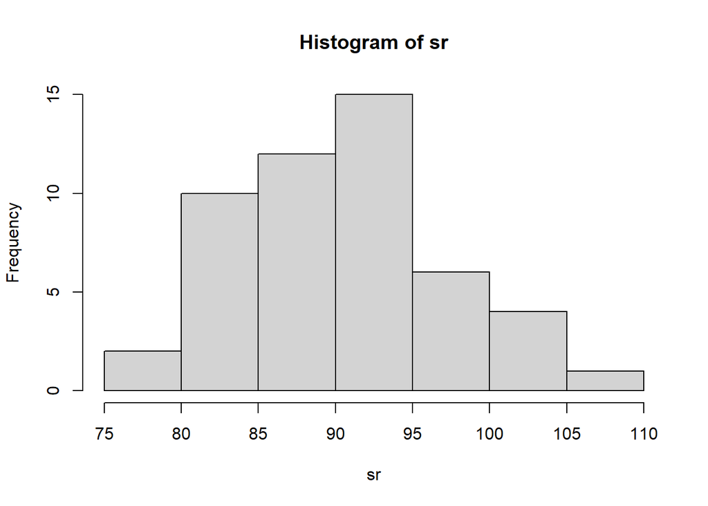

```r
sr <- rowSums(BCI > 0)
hist(sr)
```

```r
abu <- colSums(BCI)
quantile(abu)
```

```
##   0%  25%  50%  75% 100%
##    1    7   25   82 1717
```

```r
quantile(log10(abu))
```

```
##       0%      25%      50%      75%     100%
## 0.000000 0.845098 1.397940 1.913814 3.234770
```

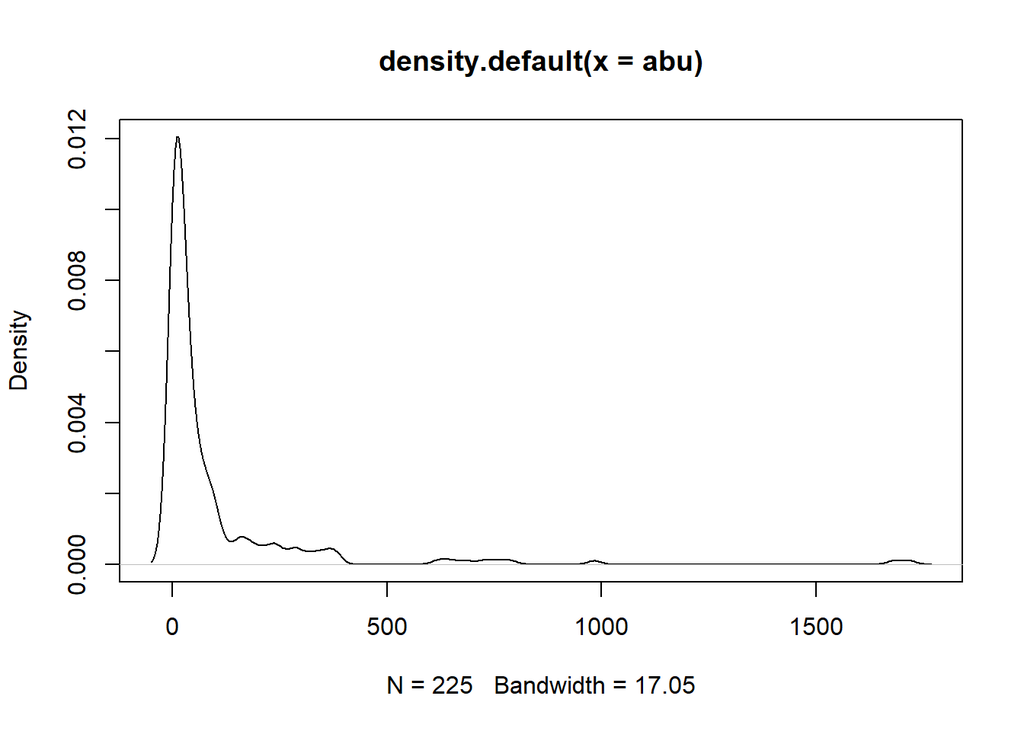

```r
plot(density(abu))
```

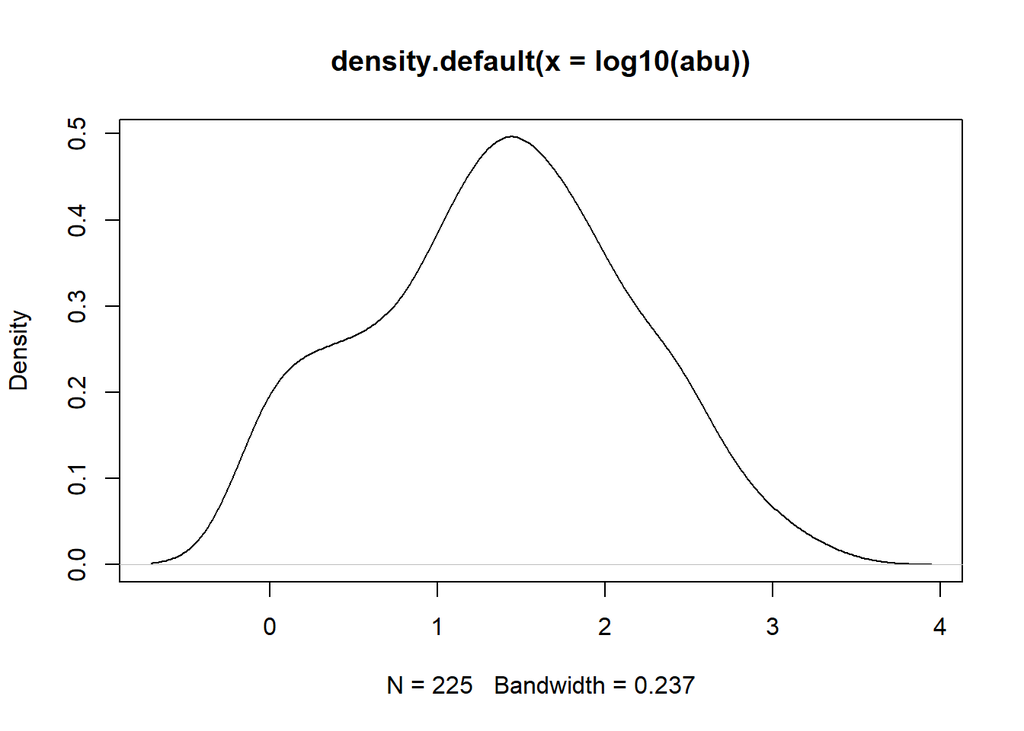

```r
plot(density(log10(abu)))
```

```r
which(abu > 25 & abu < 27)
```

```
## Erythrina.costaricensis          Inga.acuminata       Sterculia.apetala
##                      65                     100                     187
##   Symphonia.globulifera
##                     190
```

```r
which(abu > 10^1.93 & abu < 10^1.95)
```

```
## Cassipourea.guianensis   Dendropanax.arboreus
##                     32                     58
```

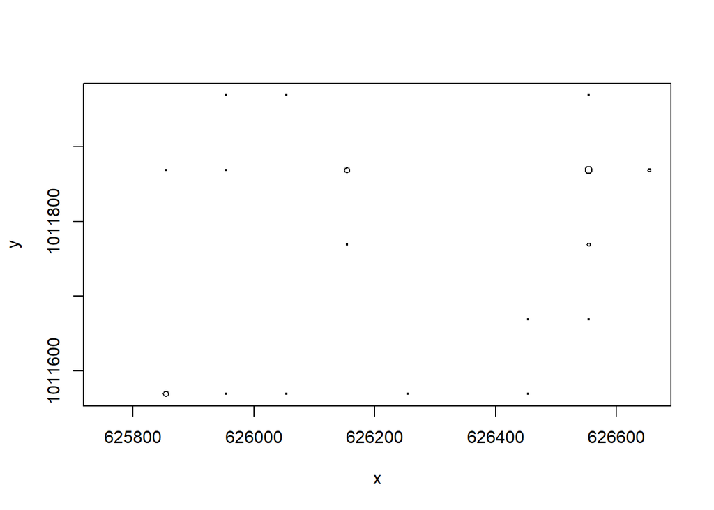

```r
rare_sp <- BCI[ , 65]
comm_sp <- BCI[ , 58]
plot(BCI_xy, cex = rare_sp / max(rare_sp))
```

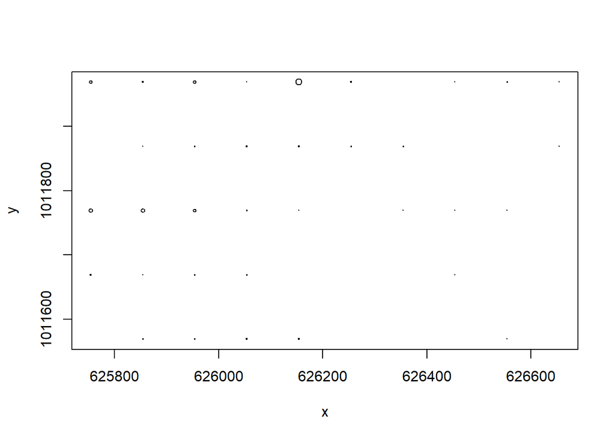

```r
plot(BCI_xy, cex = comm_sp / max(comm_sp))
```

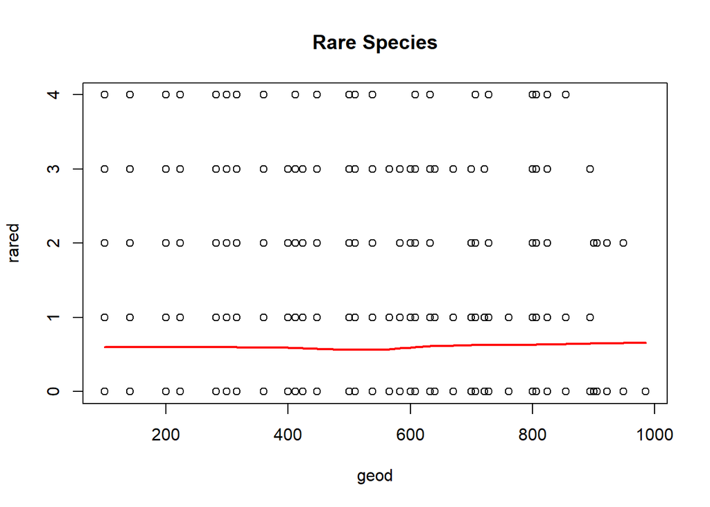

```r
geod <- dist(BCI_xy)
rared <- dist(rare_sp)
commd <- dist(comm_sp)
plot(geod, rared, main = "Rare Species")
lines(lowess(geod, rared), lwd = 2, col = "red")
```

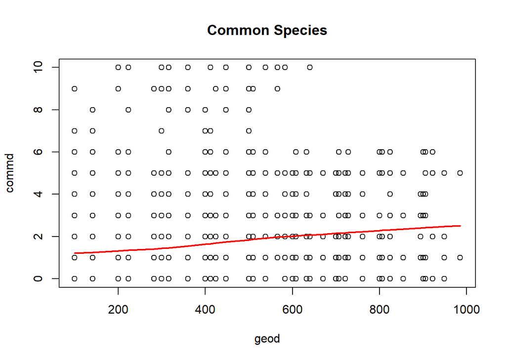

```r
plot(geod, commd, main = "Common Species")
lines(lowess(geod, commd), lwd = 2, col = "red")
```

```r
rare_mantel <- mantel(geod, rared)
rare_mantel
```

```
##
## Mantel statistic based on Pearson's product-moment correlation
##
## Call:
## mantel(xdis = geod, ydis = rared)
##
## Mantel statistic r: 0.01076
##       Significance: 0.391
##
## Upper quantiles of permutations (null model):
##    90%    95%  97.5%    99%
## 0.0745 0.0975 0.1146 0.1419
## Permutation: free
## Number of permutations: 999
```

```r
comm_mantel <- mantel(geod, commd)
comm_mantel
```

```
##
## Mantel statistic based on Pearson's product-moment correlation
##
## Call:
## mantel(xdis = geod, ydis = commd)
##
## Mantel statistic r: 0.1565
##       Significance: 0.003
##
## Upper quantiles of permutations (null model):
##    90%    95%  97.5%    99%
## 0.0752 0.0991 0.1142 0.1321
## Permutation: free
## Number of permutations: 999
```

1. Examine if there is evidence of spatial dependence in a rare and a common species in the BCI tree dataset

   There is evidence of spatial dependence in a common species (col #58) but not in the rare species (col #65) in both the graphical model and the mantel test.
2. Build two generalized linear models to predict the abundance of the species Drypetes standleyi using the abundance of other tree species in the study site. Specifically examine the following species as predictor variables:

```r
sp_ids = c("Cordia.lasiocalyx", "Hirtella.triandra",
           "Picramnia.latifolia", "Quassia.amara",
           "Tabernaemontana.arborea", "Trattinnickia.aspera",
           "Xylopia.macrantha")

sp_dry <- BCI$Drypetes.standleyi
sp_a <- BCI$Cordia.lasiocalyx
sp_b <- BCI$Hirtella.triandra
sp_c <- BCI$Picramnia.latifolia
sp_d <- BCI$Quassia.amara
sp_e <- BCI$Tabernaemontana.arborea
sp_f <- BCI$Trattinnickia.aspera
sp_g <- BCI$Xylopia.macrantha
all_sp <- sp_a + sp_b + sp_c + sp_d + sp_e + sp_f + sp_g
```

Note renaming the species ids to something a little easier to work with like “sp_a”, “sp_b” will make model construction a little less cumbersome

Model 1: only include a single species as a predictor variable

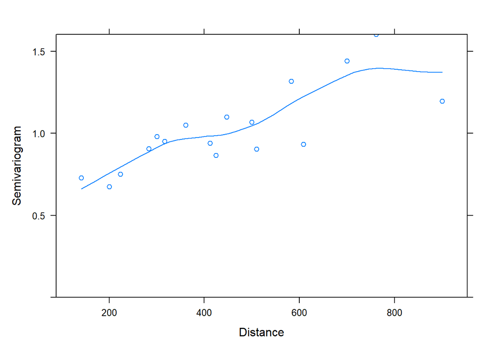

```r
library(nlme)
abu_lm = gls(sp_dry ~ sp_a, data = BCI_xy)

plot(Variogram(abu_lm, form = ~ x + y))
```

Model 2: include all of the species as predictor variables

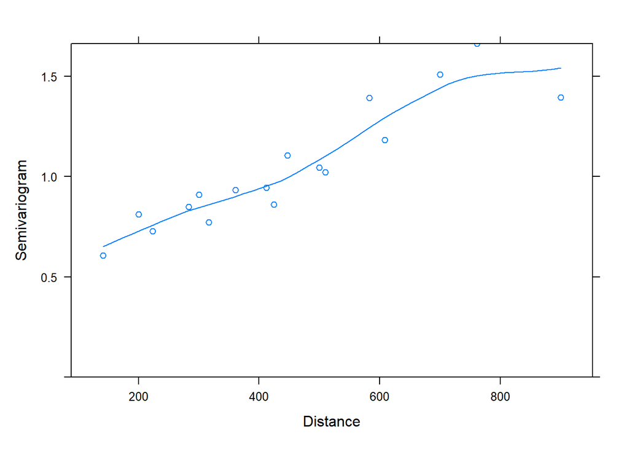

```r
sp_dry_lm = gls(sp_dry ~ all_sp, data = BCI_xy)

plot(Variogram(sp_dry_lm, form = ~ x + y))
```

With both models examine the spatial dependence of the residuals using the function Variogram. Model the spatial dependence in the residuals using one of the error structures available.

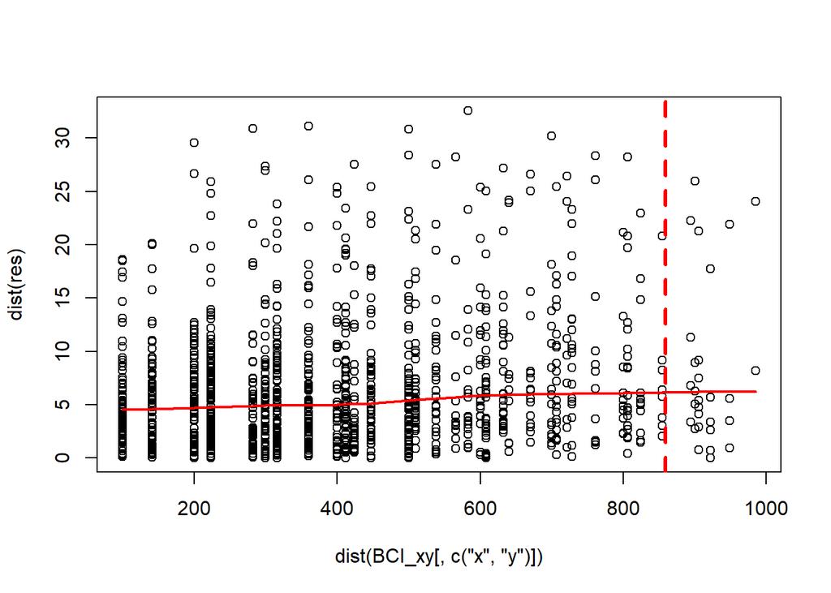

```r
max_abu <- max(abu) / 2
res = residuals(sp_dry_lm)
plot(dist(BCI_xy[, c('x', 'y')]), dist(res))
lines(lowess(dist(BCI_xy[, c('x', 'y')]), dist(res)), col='red', lwd=2)
abline(v = max_abu, col='red', lwd=3, lty=2)
```

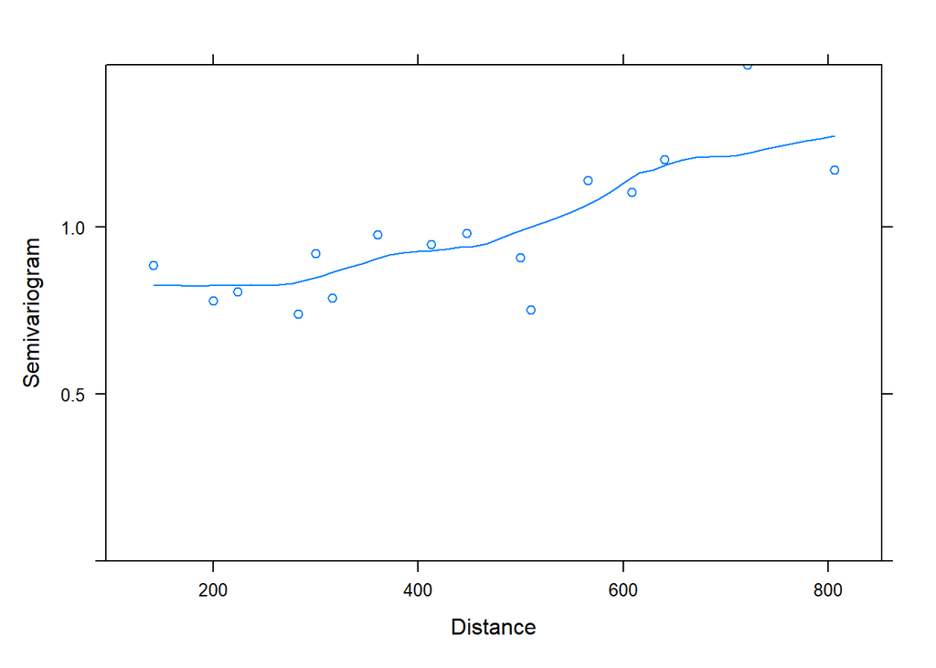

```r
sp_dry_exp = update(sp_dry_lm, corr=corExp(form=~x + y))
plot(Variogram(sp_dry_exp, resType='normalized', maxDist = max_abu))
```

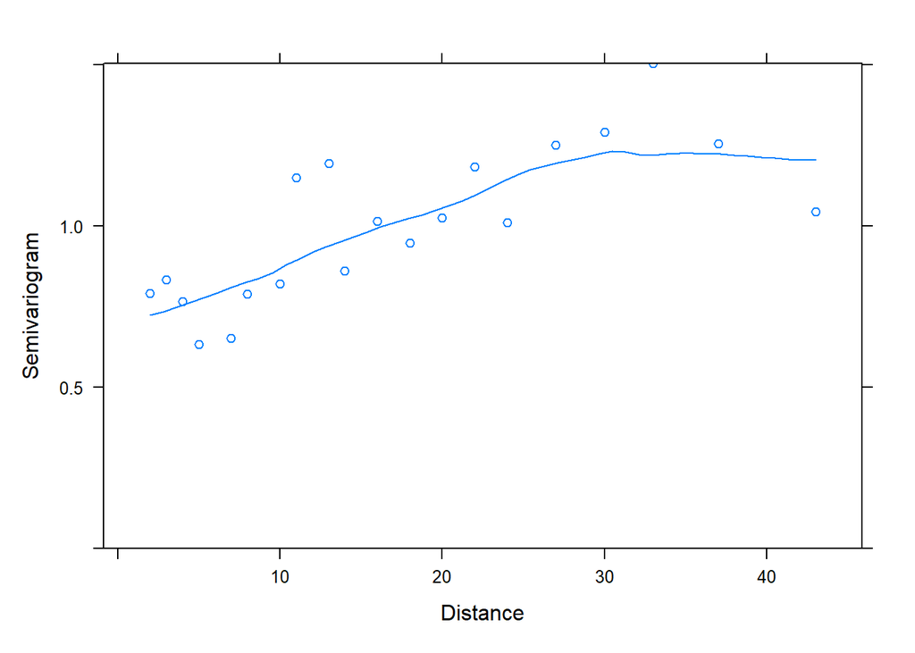

```r
sp_dry_q = update(sp_dry_lm, corr=corRatio(form=~x + y, nugget=T))
plot(Variogram(sp_dry_lm, maxDist = max_abu))
```

```r
anova(sp_dry_lm, sp_dry_exp, sp_dry_q, test=F)
```

```
##            Model df      AIC      BIC    logLik
## sp_dry_lm      1  3 333.6752 339.2888 -163.8376
## sp_dry_exp     2  4 310.4466 317.9314 -151.2233
## sp_dry_q       3  5 309.7951 319.1511 -149.8975
```

```r
summary(sp_dry_exp)
```

```
## Generalized least squares fit by REML
##   Model: sp_dry ~ all_sp
##   Data: BCI_xy
##        AIC      BIC    logLik
##   310.4466 317.9314 -151.2233
##
## Correlation Structure: Exponential spatial correlation
##  Formula: ~x + y
##  Parameter estimate(s):
##    range
## 2587.328
##
## Coefficients:
##                Value Std.Error   t-value p-value
## (Intercept) 6.870815 21.093230 0.3257356   0.746
## all_sp      0.123920  0.072083 1.7191234   0.092
##
##  Correlation:
##        (Intr)
## all_sp -0.171
##
## Standardized residuals:
##        Min         Q1        Med         Q3        Max
## -0.5265928 -0.4142621 -0.3040466 -0.1912209  1.0605794
##
## Residual standard error: 23.16663
## Degrees of freedom: 50 total; 48 residual
```

```r
summary(sp_dry_q)
```

```
## Generalized least squares fit by REML
##   Model: sp_dry ~ all_sp
##   Data: BCI_xy
##        AIC      BIC    logLik
##   309.7951 319.1511 -149.8975
##
## Correlation Structure: Rational quadratic spatial correlation
##  Formula: ~x + y
##  Parameter estimate(s):
##        range       nugget
## 714.60409598   0.05834791
##
## Coefficients:
##                Value Std.Error   t-value p-value
## (Intercept) 8.937964 12.731285 0.7020473  0.4860
## all_sp      0.080682  0.062277 1.2955316  0.2013
##
##  Correlation:
##        (Intr)
## all_sp -0.272
##
## Standardized residuals:
##        Min         Q1        Med         Q3        Max
## -0.7638153 -0.6557842 -0.5135806 -0.3035711  1.5476870
##
## Residual standard error: 16.24386
## Degrees of freedom: 50 total; 48 residual
```

Did including the spatial error term have a large impact on the coefficients of the model?

```
  Including the spatial error term had a great impact on the coefficients of the model. The p-value for the quadratic error model is much larger than that of the exponential model.
```

Did including the spatial error terms significantly improve model fit (use function anova to carry out model comparison)?

[output not shown]

Explain why you did or did not observe a difference in the influence of adding the spatial error term between the two models.

[output not shown]